# GSE93861 GEO Workflow

Krupa Navalkar

05-19-2020

```r
knitr::opts_chunk$set(echo = TRUE, message = FALSE, warning = FALSE, fig.align = "center")

cran_packages <- c("data.table", "dplyr", "forcats", "ggplot2", "knitr", "pROC",
                   "purrr", "readr", "stringr", "tibble", "tidyr", "rmarkdown")
bioc_packages <- c("Biobase", "GEOquery", "limma")

missing_cran <- cran_packages[!vapply(cran_packages, requireNamespace, logical(1), quietly = TRUE)]
missing_bioc <- bioc_packages[!vapply(bioc_packages, requireNamespace, logical(1), quietly = TRUE)]

if (length(missing_cran) > 0) {
  stop("Missing required CRAN package(s): ", paste(missing_cran, collapse = ", "),
       ". Install with install.packages().")
}
if (length(missing_bioc) > 0) {
  stop("Missing required Bioconductor package(s): ", paste(missing_bioc, collapse = ", "),
       ". Install with BiocManager::install().")
}

library(Biobase)
library(data.table)
library(dplyr)
library(forcats)
library(GEOquery)
library(ggplot2)
library(knitr)
library(limma)
library(pROC)
library(purrr)
library(readr)
library(stringr)
library(tibble)
library(tidyr)

has_pheatmap <- requireNamespace("pheatmap", quietly = TRUE)
has_ggrepel <- requireNamespace("ggrepel", quietly = TRUE)

dir.create(params$output_dir, showWarnings = FALSE, recursive = TRUE)
plot_dir <- file.path(params$output_dir, "plots")
deg_dir <- file.path(params$output_dir, "deg_outputs")
dir.create(plot_dir, showWarnings = FALSE, recursive = TRUE)
dir.create(deg_dir, showWarnings = FALSE, recursive = TRUE)

safe_auc <- function(data, response_col, predictor_col, reference_level, comparison_level, min_n_per_group = 3) {
  response_values <- as.character(data[[response_col]])
  predictor_values <- data[[predictor_col]]

  valid_rows <- !is.na(response_values) & !is.na(predictor_values)

  response_values <- response_values[valid_rows]
  predictor_values <- predictor_values[valid_rows]

  n_reference <- sum(response_values == reference_level)
  n_comparison <- sum(response_values == comparison_level)

  if (n_reference < min_n_per_group || n_comparison < min_n_per_group) {
    return(NA_real_)
  }

  if (!all(c(reference_level, comparison_level) %in% response_values)) {
    return(NA_real_)
  }

  if (length(unique(response_values)) < 2 || length(predictor_values) < 2) {
    return(NA_real_)
  }

  as.numeric(
    round(
      pROC::auc(
        response = factor(response_values, levels = c(reference_level, comparison_level)),
        predictor = predictor_values,
        levels = c(reference_level, comparison_level),
        quiet = TRUE
      ),
      2
    )
  )
}
```

# 1 Purpose

This workflow starts by downloading GSE93861 directly from GEO. It preserves original GEO gene symbols for genome-wide analyses including differential-expression tables, volcano plots, MA plots, PCA plots, and heatmaps.

Only the signature names and the signature-component gene names listed in the original script are masked in the report. The signature calculations are performed using the formulas from the original script, but the calculation code is hidden from the rendered HTML.

Case/control labels are harmonized as:

- Ebola-derived samples: `CASE`
- Healthy samples: `Control group`

# 2 Download GSE93861 from GEO

```r
geo_object <- GEOquery::getGEO(params$gse_accession, GSEMatrix = TRUE, getGPL = TRUE)

if (length(geo_object) > 1) {
  geo_names <- attr(geo_object, "names")
  geo_index <- grep(params$gpl_platform, geo_names)
  if (length(geo_index) == 0) stop("Requested GPL platform was not found: ", params$gpl_platform)
  geo_index <- geo_index[1]
} else {
  geo_index <- 1
}

geo_set <- geo_object[[geo_index]]

sample_metadata_raw <- Biobase::pData(geo_set)
feature_metadata_raw <- Biobase::fData(geo_set)
expression_matrix_raw <- Biobase::exprs(geo_set)

expression_quantiles <- quantile(expression_matrix_raw, probs = c(0, 0.25, 0.50, 0.75, 0.99, 1), na.rm = TRUE)

requires_log2 <- (expression_quantiles[5] > 100) ||
  (expression_quantiles[6] - expression_quantiles[1] > 50 && expression_quantiles[2] > 0) ||
  (expression_quantiles[2] > 0 && expression_quantiles[2] < 1 && expression_quantiles[4] > 1 && expression_quantiles[4] < 2)

if (requires_log2) {
  expression_matrix_raw[expression_matrix_raw <= 0] <- NA_real_
  expression_matrix_raw <- log2(expression_matrix_raw)
}

write_csv(as_tibble(sample_metadata_raw), file.path(params$output_dir, "GSE93861_all_metadata_from_GEO.csv"))

tibble(
  accession = params$gse_accession,
  platform = params$gpl_platform,
  n_probes = nrow(expression_matrix_raw),
  n_samples = ncol(expression_matrix_raw),
  log2_transform_applied = requires_log2
)
```

| accession | platform | n_probes | n_samples | log2_transform_applied |
| --- | --- | --- | --- | --- |
| GSE93861 | GPL6480 | 41000 | 79 | TRUE |

# 3 Prepare sample metadata

```r
sample_metadata <- tibble(
  sample_id = sample_metadata_raw$geo_accession,
  source_group_raw = sample_metadata_raw$source_name_ch1,
  sample_label_raw = sample_metadata_raw$title
) %>%
  separate(sample_label_raw, into = c("patient_id", "day_raw", "replicate_raw"),
           sep = "-", remove = FALSE, fill = "right") %>%
  mutate(
    case_status = if_else(patient_id == "Ebola", "CASE", "Control group"),
    replicate_group = sample_label_raw %>%
      str_remove(regex("-replicate 1", ignore_case = TRUE)) %>%
      str_remove(regex("-replicate 2", ignore_case = TRUE)) %>%
      str_remove(regex("-replicate 3", ignore_case = TRUE)) %>%
      str_replace_all(regex("healthy blood", ignore_case = TRUE), "Control_group") %>%
      str_replace_all(" ", "") %>%
      str_replace_all("-", "_") %>%
      str_replace(regex("^Ebola", ignore_case = TRUE), "CASE")
  ) %>%
  select(sample_id, source_group_raw, sample_label_raw, patient_id, day_raw,
         replicate_raw, replicate_group, case_status)

sample_metadata %>% count(case_status)
```

| case_status | n |
| --- | --- |
| CASE | 49 |
| Control group | 30 |

# 4 Collapse duplicate probes to original GEO gene symbols

```r
if (!"GENE_SYMBOL" %in% names(feature_metadata_raw)) {
  stop("Expected feature metadata column GENE_SYMBOL was not found.")
}

expression_by_probe <- as.data.frame(expression_matrix_raw) %>%
  rownames_to_column("probe_id") %>%
  mutate(gene_symbol = feature_metadata_raw$GENE_SYMBOL) %>%
  filter(!is.na(gene_symbol), gene_symbol != "") %>%
  mutate(gene_symbol = str_replace_all(gene_symbol, " ", "-")) %>%
  filter(!str_detect(gene_symbol, "^LOC"))

sample_columns <- setdiff(names(expression_by_probe), c("probe_id", "gene_symbol"))

expression_by_gene <- expression_by_probe %>%
  mutate(mean_probe_expression = rowMeans(across(all_of(sample_columns)), na.rm = TRUE)) %>%
  filter(is.finite(mean_probe_expression)) %>%
  arrange(gene_symbol, desc(mean_probe_expression)) %>%
  group_by(gene_symbol) %>%
  slice(1) %>%
  ungroup() %>%
  select(-probe_id, -mean_probe_expression) %>%
  column_to_rownames("gene_symbol")

expression_by_sample <- expression_by_gene %>%
  t() %>%
  as.data.frame() %>%
  rownames_to_column("sample_id")

tibble(
  n_genes_after_probe_collapse = nrow(expression_by_gene),
  n_samples = ncol(expression_by_gene)
)
```

| n_genes_after_probe_collapse | n_samples |
| --- | --- |
| 18437 | 79 |

# 5 Average technical replicates

```r
analysis_matrix <- sample_metadata %>%
  select(sample_id, replicate_group, case_status) %>%
  inner_join(expression_by_sample, by = "sample_id") %>%
  select(-sample_id) %>%
  group_by(replicate_group, case_status) %>%
  summarise(across(where(is.numeric), ~ mean(.x, na.rm = TRUE)), .groups = "drop") %>%
  mutate(
    case_status = factor(case_status, levels = c("Control group", "CASE")),
    day_numeric = replicate_group %>%
      str_remove(regex("^CASE_Day", ignore_case = TRUE)) %>%
      str_replace_all("Control_group|Controlgroup", "0") %>%
      as.numeric(),
    day_window = case_when(
      case_status == "Control group" ~ "Control group",
      !is.na(day_numeric) & day_numeric >= 7 & day_numeric <= 13 ~ "Days_7-13",
      !is.na(day_numeric) & day_numeric > 13 & day_numeric <= 20 ~ "Days_14-20",
      !is.na(day_numeric) & day_numeric > 20 & day_numeric <= 33 ~ "Days_21-33",
      !is.na(day_numeric) & day_numeric > 33 & day_numeric <= 58 ~ "Days_34-58",
      !is.na(day_numeric) & day_numeric > 58 & day_numeric <= 180 ~ "Days_59-180",
      !is.na(day_numeric) & day_numeric >180 & day_numeric <= 270 ~ "Days_181-270",
      TRUE ~ NA_character_
    ),
    day_window = factor(day_window, levels = c("Days_7-13", "Days_14-20", "Days_21-33",
                                               "Days_34-58", "Days_59-180", "Days_181-270", "Control group"))
  )

analysis_matrix %>% count(case_status, day_window)
```

| case_status | day_window | n |
| --- | --- | --- |
| Control group | Control group | 30 |
| CASE | Days_7-13 | 7 |
| CASE | Days_14-20 | 7 |
| CASE | Days_21-33 | 7 |
| CASE | Days_59-180 | 3 |
| CASE | Days_181-270 | 1 |

# 6 Signature calculations

The following score columns are calculated using the same gene combinations and directions as the original script. The calculation code is intentionally hidden from the rendered report. Only masked score labels are used downstream.

# 7 Signature score summaries

```r
signature_long %>%
  group_by(signature_label, case_status) %>%
  summarise(
    n = sum(!is.na(score_value)),
    median = median(score_value, na.rm = TRUE),
    IQR = IQR(score_value, na.rm = TRUE),
    .groups = "drop"
  )
```

| signature_label | case_status | n | median | IQR |
| --- | --- | --- | --- | --- |
| Score 1 | Control group | 30 | 7.1481335 | 1.3666017 |
| Score 1 | CASE | 25 | 9.0314480 | 2.2283380 |
| Score 2 | Control group | 30 | -3.3452332 | 2.0406685 |
| Score 2 | CASE | 25 | -1.5065508 | 4.9791080 |
| Score 3 | Control group | 30 | -2.8779236 | 1.1059463 |
| Score 3 | CASE | 25 | 0.9748004 | 3.6996460 |
| Score 4 | Control group | 30 | -11.0996048 | 1.4291170 |
| Score 4 | CASE | 25 | -7.4489436 | 4.9393913 |
| Score 5 | Control group | 30 | 4.9308189 | 0.7877443 |
| Score 5 | CASE | 25 | 7.1296350 | 2.0547648 |

# 8 Signature AUC summaries

AUC is reported as `NA` when either group has fewer than 3 non-missing samples for the relevant comparison.

```r
case_control_auc <- tibble()

for (current_signature_id in signature_ids) {
  current_label <- signature_label_key$signature_label[signature_label_key$signature_id == current_signature_id]
  current_data <- signature_long %>% filter(signature_id == current_signature_id, !is.na(score_value), !is.na(case_status))

  case_control_auc <- bind_rows(
    case_control_auc,
    tibble(
      signature_label = current_label,
      comparison_group = "CASE",
      reference_group = "Control group",
      auc = safe_auc(current_data, "case_status", "score_value", "Control group", "CASE"),
      n_reference = sum(as.character(current_data$case_status) == "Control group", na.rm = TRUE),
      n_comparison = sum(as.character(current_data$case_status) == "CASE", na.rm = TRUE)
    )
  )
}

observed_window_levels <- analysis_matrix %>%
  filter(!is.na(day_window), day_window != "Control group") %>%
  distinct(day_window) %>%
  arrange(day_window) %>%
  pull(day_window) %>%
  as.character()

window_auc <- tibble()

for (current_window in observed_window_levels) {
  for (current_signature_id in signature_ids) {
    current_label <- signature_label_key$signature_label[signature_label_key$signature_id == current_signature_id]

    current_data <- signature_long %>%
      filter(signature_id == current_signature_id,
             day_window %in% c("Control group", current_window),
             !is.na(score_value),
             !is.na(day_window)) %>%
      mutate(day_window = factor(as.character(day_window), levels = c("Control group", current_window)))

    window_auc <- bind_rows(
      window_auc,
      tibble(
        signature_label = current_label,
        comparison_group = current_window,
        reference_group = "Control group",
        auc = safe_auc(current_data, "day_window", "score_value", "Control group", current_window),
        n_reference = sum(as.character(current_data$day_window) == "Control group", na.rm = TRUE),
        n_comparison = sum(as.character(current_data$day_window) == current_window, na.rm = TRUE)
      )
    )
  }
}

write_csv(case_control_auc, file.path(params$output_dir, "GSE93861_signature_case_control_auc_masked.csv"))
write_csv(window_auc, file.path(params$output_dir, "GSE93861_signature_day_window_auc_masked.csv"))

window_auc
```

| signature_label | comparison_group | reference_group | auc | n_reference | n_comparison |
| --- | --- | --- | --- | --- | --- |
| Score 1 | Days_7-13 | Control group | 0.99 | 30 | 7 |
| Score 2 | Days_7-13 | Control group | 1.00 | 30 | 7 |
| Score 3 | Days_7-13 | Control group | 1.00 | 30 | 7 |
| Score 4 | Days_7-13 | Control group | 1.00 | 30 | 7 |
| Score 5 | Days_7-13 | Control group | 1.00 | 30 | 7 |
| Score 1 | Days_14-20 | Control group | 0.98 | 30 | 7 |
| Score 2 | Days_14-20 | Control group | 0.80 | 30 | 7 |
| Score 3 | Days_14-20 | Control group | 1.00 | 30 | 7 |
| Score 4 | Days_14-20 | Control group | 1.00 | 30 | 7 |
| Score 5 | Days_14-20 | Control group | 0.99 | 30 | 7 |

[output cut: 15 more lines]

# 9 Signature plots with masked labels

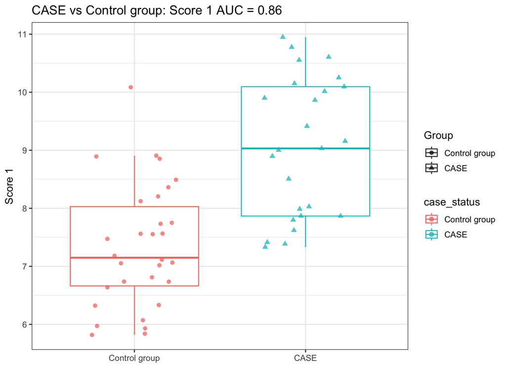

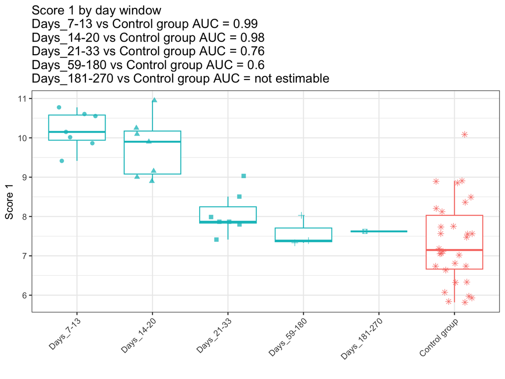

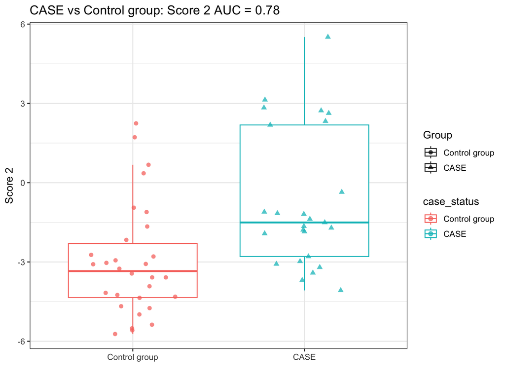

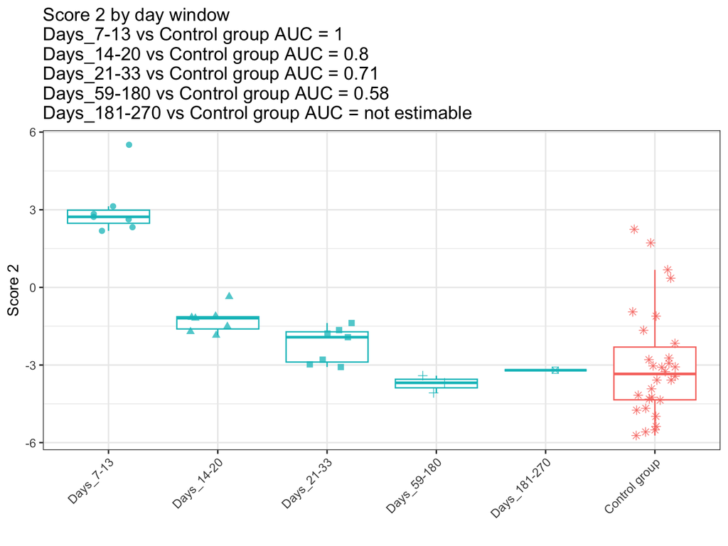

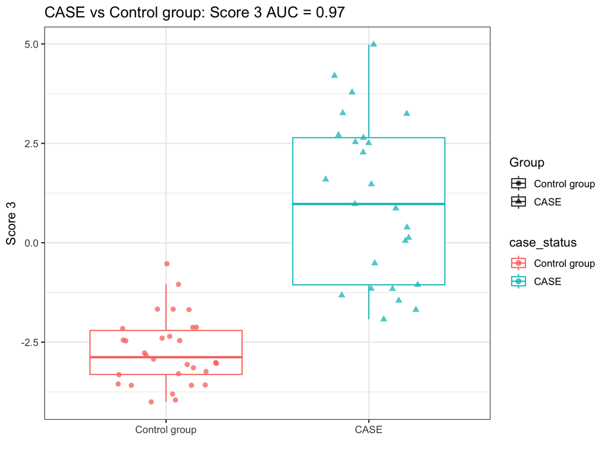

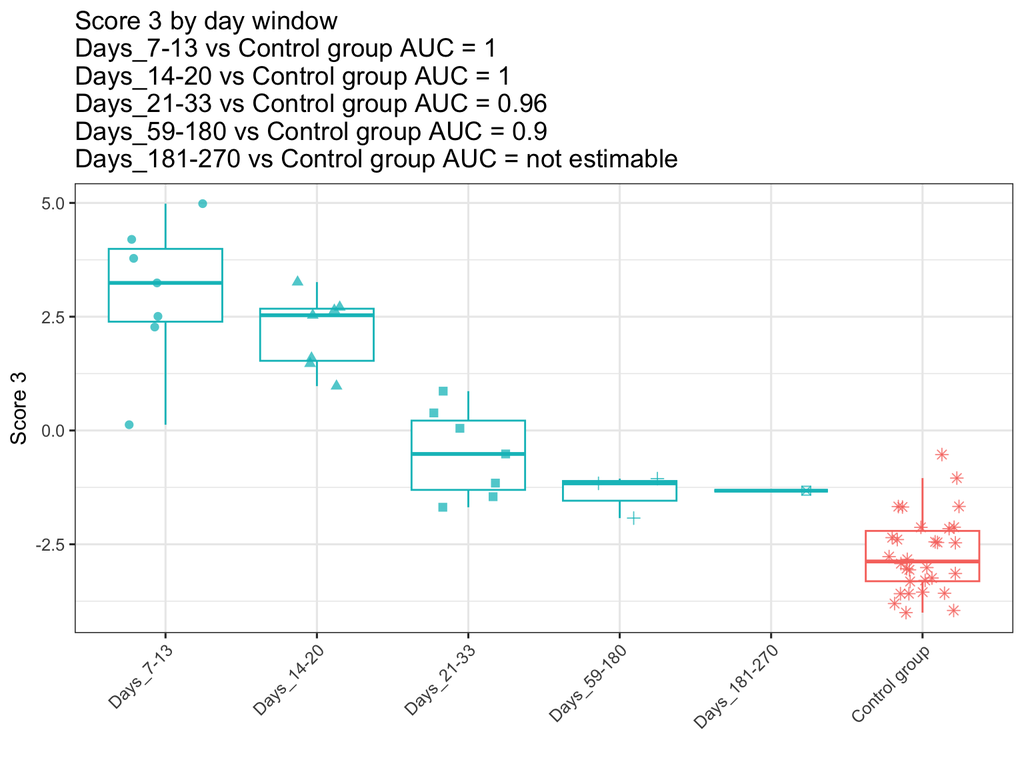

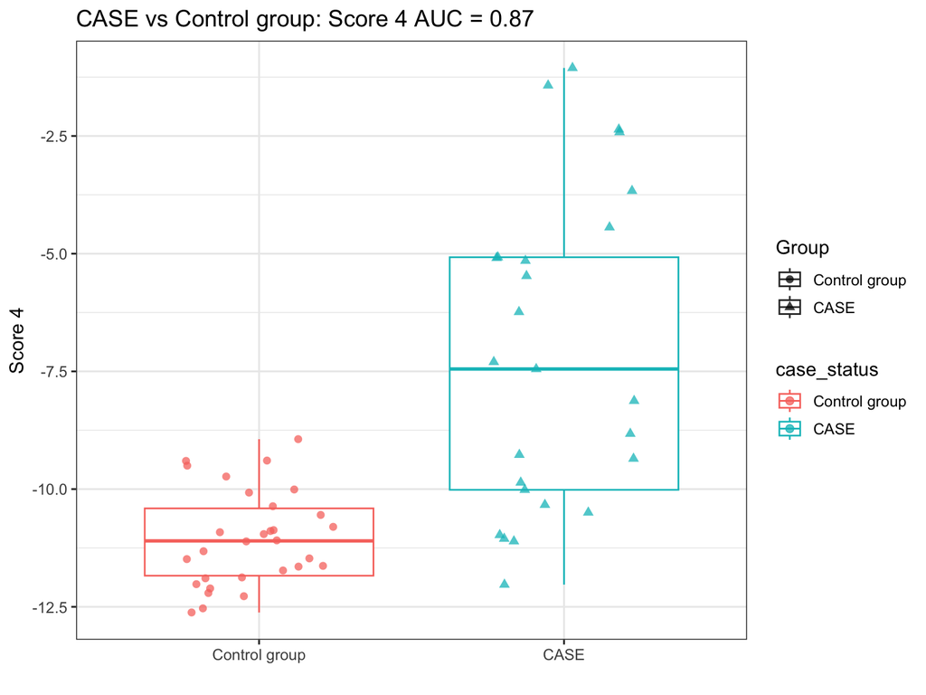

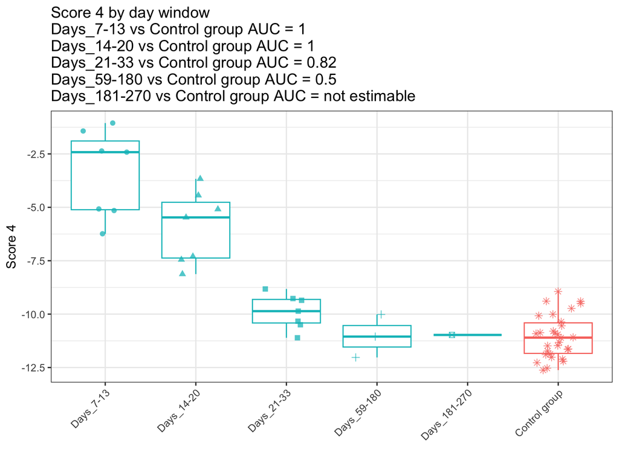

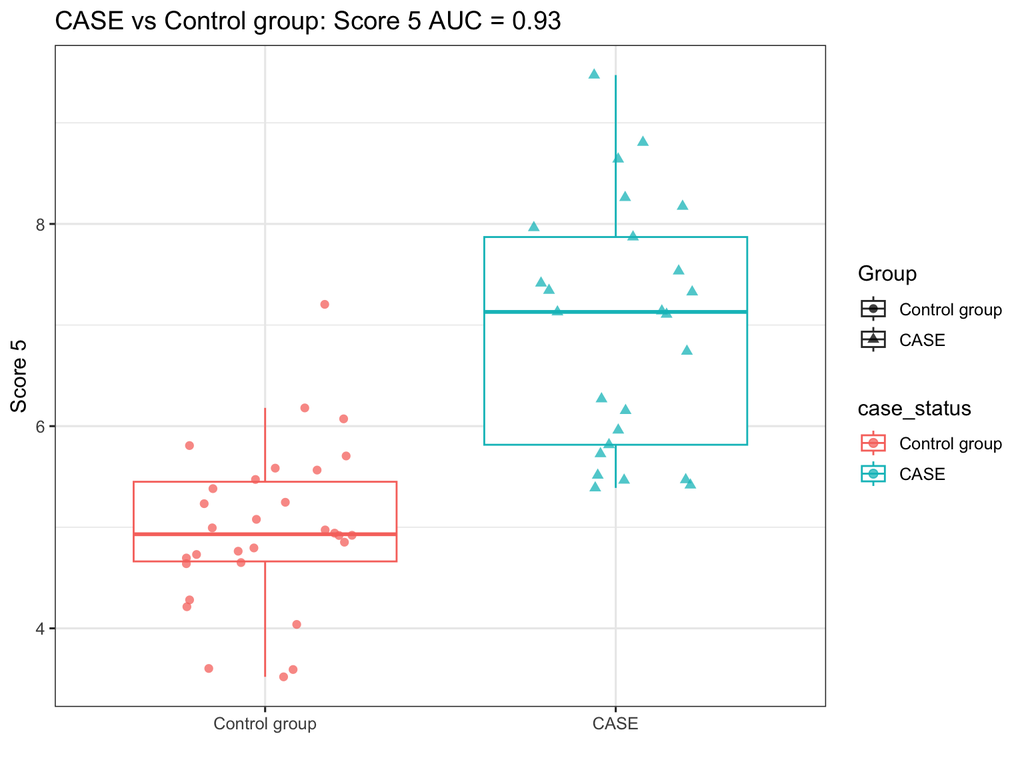

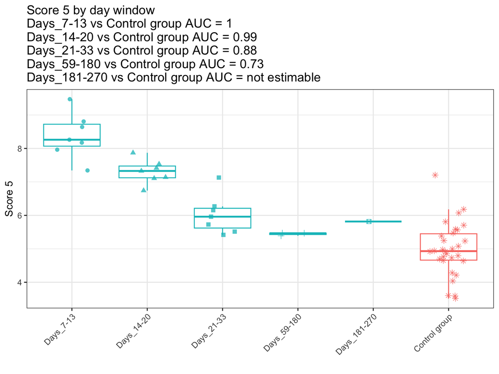

```r
signature_plot_objects <- list()

for (current_signature_id in signature_ids) {
  current_label <- signature_label_key$signature_label[signature_label_key$signature_id == current_signature_id]
  current_case_auc <- case_control_auc$auc[case_control_auc$signature_label == current_label]
  current_auc_label <- ifelse(is.na(current_case_auc), "not estimable", current_case_auc)
  current_signature_data <- signature_long %>% filter(signature_id == current_signature_id)

  case_plot <- ggplot(current_signature_data, aes(x = case_status, y = score_value, shape = case_status, color = case_status)) +
    geom_boxplot(outlier.shape = NA) +
    geom_point(position = position_jitter(width = 0.25), alpha = 0.75, size = 2) +
    theme_bw(base_size = 12) +
    labs(title = paste0("CASE vs Control group: ", current_label, " AUC = ", current_auc_label),
         x = "", y = current_label, shape = "Group")

  signature_plot_objects[[paste0(current_signature_id, "_case_control")]] <- case_plot

  ggsave(file.path(plot_dir, paste0(current_label, "_case_control.png")),
         case_plot, width = 8, height = 6, dpi = 300)

  current_window_auc <- window_auc %>%
    filter(signature_label == current_label) %>%
    mutate(auc_label = if_else(is.na(auc), "not estimable", as.character(auc)),
           label_line = paste0(comparison_group, " vs Control group AUC = ", auc_label)) %>%
    pull(label_line) %>%
    paste(collapse = "\n")

  window_plot <- ggplot(current_signature_data, aes(x = day_window, y = score_value, shape = day_window, color = case_status)) +
    geom_boxplot(outlier.shape = NA) +
    geom_point(position = position_jitter(width = 0.25), alpha = 0.75, size = 2) +
    theme_bw(base_size = 12) +
    theme(axis.text.x = element_text(angle = 45, hjust = 1), legend.position = "none") +
    labs(title = paste0(current_label, " by day window\n", current_window_auc),
         x = "", y = current_label)

  signature_plot_objects[[paste0(current_signature_id, "_day_windows")]] <- window_plot

  ggsave(file.path(plot_dir, paste0(current_label, "_day_windows.png")),
         window_plot, width = 9, height = 6, dpi = 300)
}

signature_plot_objects
```

# 10 Signature time-course plots with masked labels

```r
time_order <- c(7, 8, 9, 10, 11, 12, 13, 14, 15, 16, 17, 18, 19, 20, 21, 22, 24, 25, 28, 31, 33, 59, 103, 180, 270)

time_plot_data <- signature_long %>%
  filter(case_status == "CASE", !is.na(day_numeric)) %>%
  mutate(day_numeric = factor(day_numeric, levels = time_order, ordered = TRUE))

for (current_signature_id in signature_ids) {
  current_label <- signature_label_key$signature_label[signature_label_key$signature_id == current_signature_id]

  current_time_plot <- time_plot_data %>%
    filter(signature_id == current_signature_id) %>%
    ggplot(aes(x = day_numeric, y = score_value, group = 1)) +
    geom_line() +
    geom_point(size = 2) +
    theme_bw(base_size = 12) +
    theme(axis.text.x = element_text(angle = 45, hjust = 1)) +
    labs(title = paste0(current_label, " over time"), x = "Day", y = current_label)

  signature_plot_objects[[paste0(current_signature_id, "_time_course")]] <- current_time_plot

  ggsave(file.path(plot_dir, paste0(current_label, "_time_course.png")),
         current_time_plot, width = 9, height = 5, dpi = 300)
}
```

# 11 Differential expression using original GEO gene names

For the following genome-wide analyses, original GEO gene symbols are retained in the results and figure labels.

```r
metadata_columns <- c("replicate_group", "case_status", "day_numeric", "day_window", signature_ids)
expression_feature_columns <- setdiff(names(analysis_matrix), metadata_columns)

deg_input <- analysis_matrix %>%
  select(replicate_group, case_status, all_of(expression_feature_columns)) %>%
  filter(!is.na(case_status))

deg_group <- droplevels(factor(deg_input$case_status, levels = c("Control group", "CASE")))

deg_matrix <- deg_input %>%
  select(all_of(expression_feature_columns)) %>%
  as.data.frame()

rownames(deg_matrix) <- deg_input$replicate_group
deg_matrix <- t(as.matrix(deg_matrix))
storage.mode(deg_matrix) <- "numeric"

feature_keep <- rowSums(is.finite(deg_matrix)) == ncol(deg_matrix) &
  apply(deg_matrix, 1, sd, na.rm = TRUE) > 0

deg_matrix <- deg_matrix[feature_keep, , drop = FALSE]

design_matrix <- model.matrix(~ 0 + deg_group)
colnames(design_matrix) <- make.names(levels(deg_group))

if (!all(c("Control.group", "CASE") %in% colnames(design_matrix))) {
  stop("The DEG design matrix does not contain both CASE and Control group columns.")
}

contrast_matrix <- limma::makeContrasts(CASE_vs_Control = CASE - Control.group, levels = design_matrix)
limma_fit <- limma::lmFit(deg_matrix, design_matrix)
limma_fit <- limma::contrasts.fit(limma_fit, contrast_matrix)
limma_fit <- limma::eBayes(limma_fit)

deg_results <- limma::topTable(limma_fit, coef = "CASE_vs_Control", number = Inf, sort.by = "P") %>%
  rownames_to_column("gene_symbol") %>%
  mutate(
    comparison = "CASE_vs_Control_group",
    minus_log10_adj_p = -log10(adj.P.Val),
    significance_class = case_when(
      adj.P.Val < 0.05 & logFC > 1 ~ "Higher in CASE",
      adj.P.Val < 0.05 & logFC < -1 ~ "Higher in Control group",
      TRUE ~ "Not significant"
    )
  )

write_csv(deg_results, file.path(deg_dir, "GSE93861_DEG_CASE_vs_Control_group_original_gene_names.csv"))

deg_summary <- deg_results %>%
  count(significance_class, name = "n_genes") %>%
  arrange(desc(n_genes))

deg_summary
```

| significance_class | n_genes |
| --- | --- |
| Not significant | 6809 |
| Higher in CASE | 1343 |
| Higher in Control group | 418 |

# 12 DEG summary plot

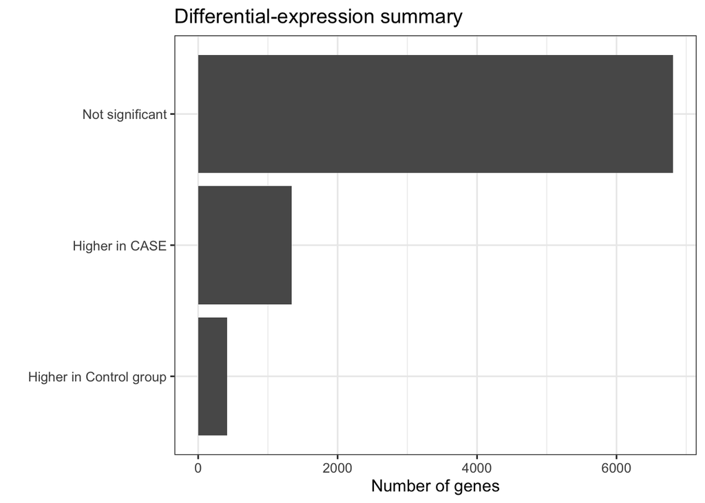

```r
deg_summary_plot <- ggplot(deg_summary, aes(x = fct_reorder(significance_class, n_genes), y = n_genes)) +
  geom_col() +
  coord_flip() +
  theme_bw(base_size = 12) +
  labs(title = "Differential-expression summary", x = "", y = "Number of genes")

ggsave(file.path(deg_dir, "GSE93861_DEG_summary_original_gene_names.png"),
       deg_summary_plot, width = 7, height = 5, dpi = 300)

deg_summary_plot
```

# 13 Volcano plot with original GEO gene names

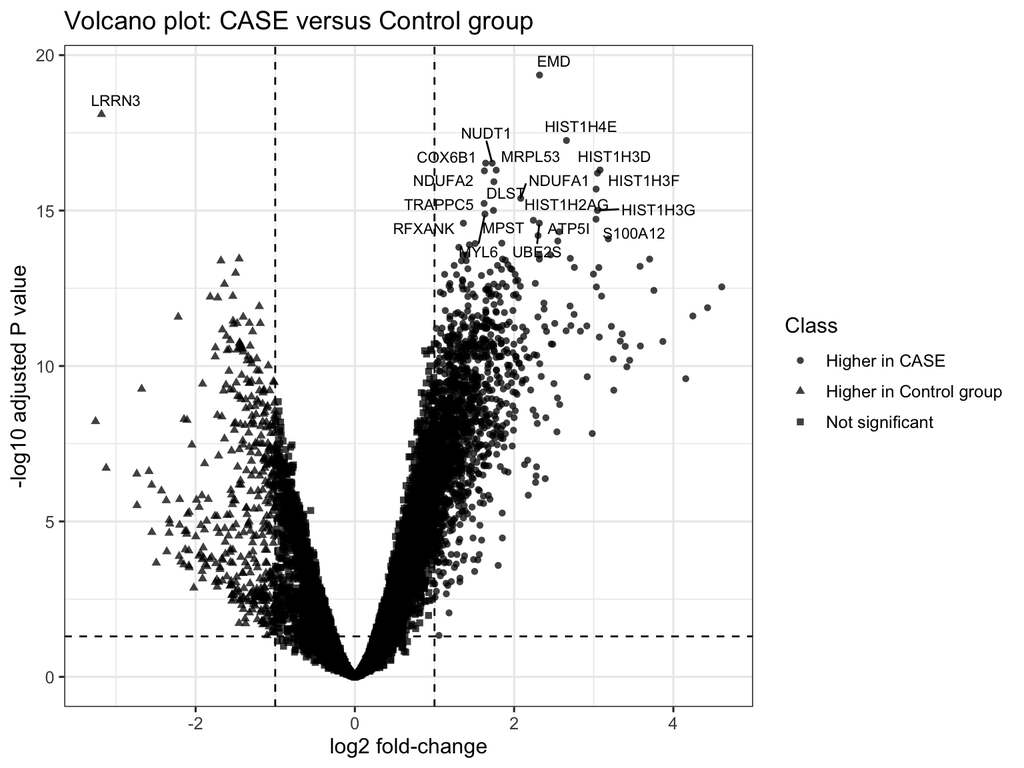

```r
volcano_plot_data <- deg_results %>%
  mutate(display_label = if_else(adj.P.Val < 0.05 & abs(logFC) >= 1, gene_symbol, NA_character_))

volcano_plot <- ggplot(volcano_plot_data, aes(x = logFC, y = minus_log10_adj_p)) +
  geom_point(aes(shape = significance_class), alpha = 0.75) +
  geom_vline(xintercept = c(-1, 1), linetype = "dashed") +
  geom_hline(yintercept = -log10(0.05), linetype = "dashed") +
  theme_bw(base_size = 12) +
  labs(title = "Volcano plot: CASE versus Control group",
       x = "log2 fold-change",
       y = "-log10 adjusted P value",
       shape = "Class")

if (has_ggrepel) {
  volcano_plot <- volcano_plot +
    ggrepel::geom_text_repel(
      data = volcano_plot_data %>% filter(!is.na(display_label)) %>% arrange(adj.P.Val) %>% slice_head(n = 20),
      aes(label = display_label),
      size = 3,
      max.overlaps = 20
    )
}

ggsave(file.path(deg_dir, "GSE93861_volcano_CASE_vs_Control_group_original_gene_names.png"),
       volcano_plot, width = 8, height = 6, dpi = 300)

volcano_plot
```

# 14 MA plot with original GEO gene names

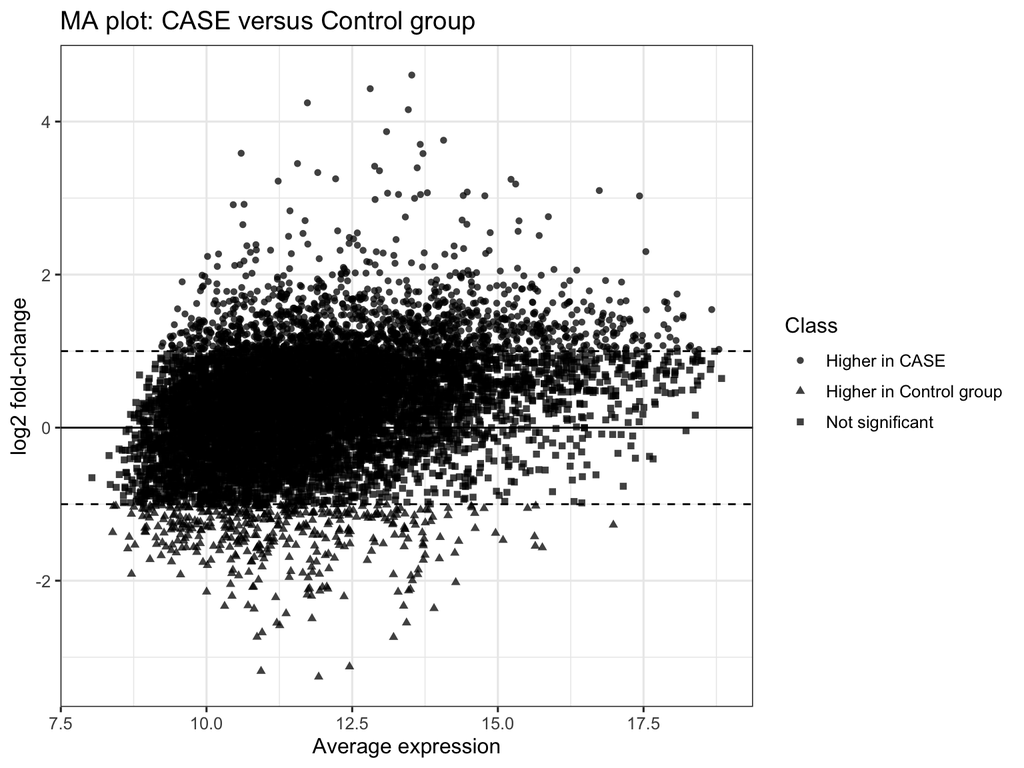

```r
ma_plot <- ggplot(deg_results, aes(x = AveExpr, y = logFC)) +
  geom_point(aes(shape = significance_class), alpha = 0.75) +
  geom_hline(yintercept = c(-1, 0, 1), linetype = c("dashed", "solid", "dashed")) +
  theme_bw(base_size = 12) +
  labs(title = "MA plot: CASE versus Control group",
       x = "Average expression",
       y = "log2 fold-change",
       shape = "Class")

ggsave(file.path(deg_dir, "GSE93861_MA_CASE_vs_Control_group_original_gene_names.png"),
       ma_plot, width = 8, height = 6, dpi = 300)

ma_plot
```

# 15 Heatmap of top DEGs with original GEO gene names

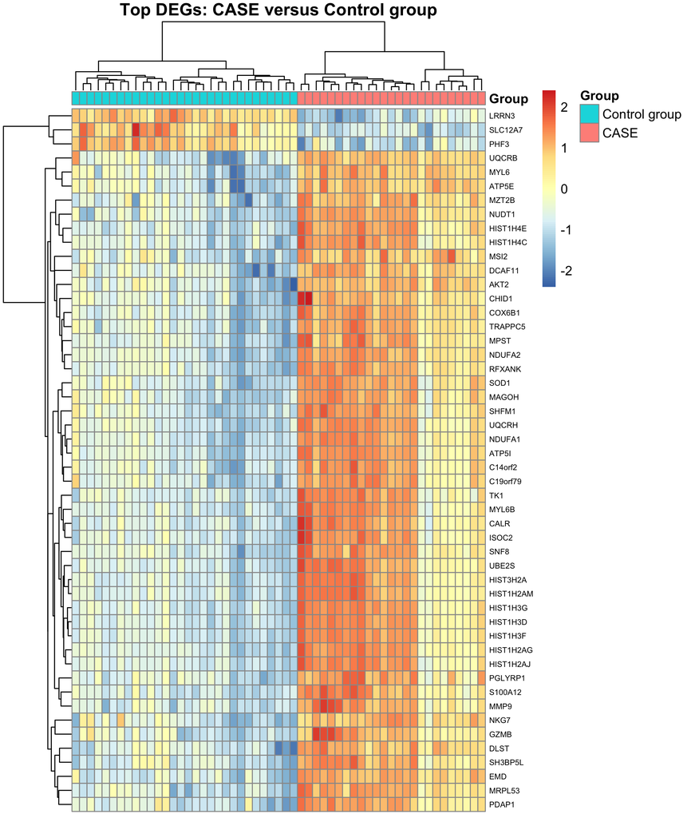

```r
top_heatmap_genes <- deg_results %>%
  arrange(adj.P.Val, desc(abs(logFC))) %>%
  slice_head(n = 50) %>%
  pull(gene_symbol)

heatmap_matrix <- deg_matrix[top_heatmap_genes, , drop = FALSE]
heatmap_matrix_scaled <- t(scale(t(heatmap_matrix)))
heatmap_matrix_scaled[!is.finite(heatmap_matrix_scaled)] <- 0

annotation_col <- data.frame(Group = deg_group)
rownames(annotation_col) <- colnames(heatmap_matrix_scaled)

heatmap_file <- file.path(deg_dir, "GSE93861_heatmap_top_DEG_CASE_vs_Control_group_original_gene_names.png")

if (has_pheatmap) {
  png(heatmap_file, width = 2200, height = 2600, res = 300)

  pheatmap::pheatmap(
    heatmap_matrix_scaled,
    annotation_col = annotation_col,
    show_colnames = FALSE,
    show_rownames = TRUE,
    fontsize_row = 6,
    main = "Top DEGs: CASE versus Control group"
  )

  dev.off()

  knitr::include_graphics(heatmap_file)
} else {
  heatmap_long <- as.data.frame(heatmap_matrix_scaled) %>%
    rownames_to_column("gene_symbol") %>%
    pivot_longer(-gene_symbol, names_to = "sample_id", values_to = "scaled_expression")

  heatmap_fallback <- ggplot(heatmap_long, aes(x = sample_id, y = gene_symbol, fill = scaled_expression)) +
    geom_tile() +
    theme_bw(base_size = 10) +
    theme(axis.text.x = element_blank(), axis.ticks.x = element_blank()) +
    labs(title = "Top DEGs: CASE versus Control group",
         x = "Samples",
         y = "Gene symbol",
         fill = "Scaled expression")

  ggsave(heatmap_file, heatmap_fallback, width = 8, height = 9, dpi = 300)

  heatmap_fallback
}
```

# 16 PCA using top DEGs with original GEO gene names

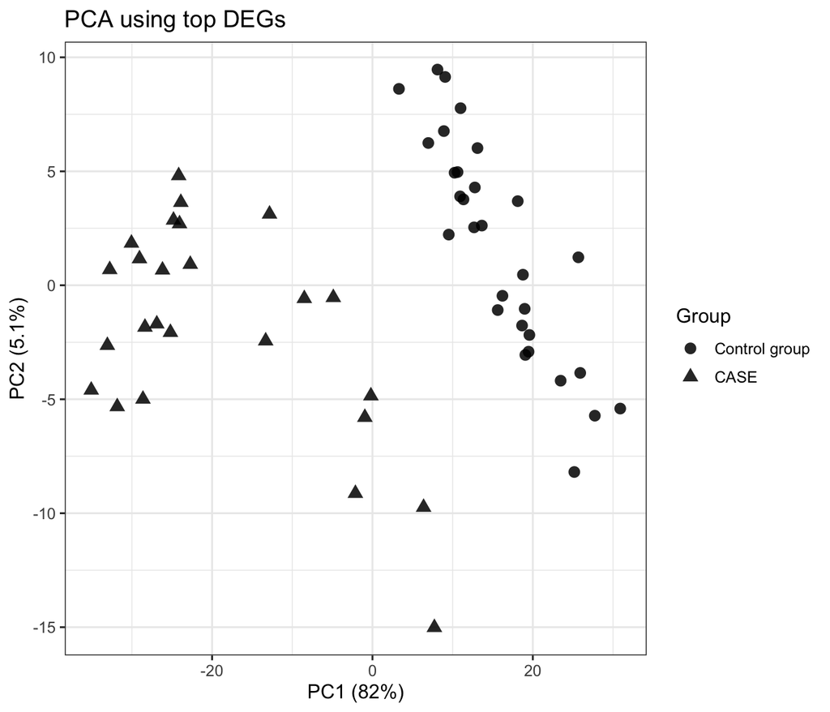

```r
top_pca_genes <- deg_results %>%
  arrange(adj.P.Val, desc(abs(logFC))) %>%
  slice_head(n = 500) %>%
  pull(gene_symbol)

pca_matrix <- t(deg_matrix[top_pca_genes, , drop = FALSE])
pca_matrix <- scale(pca_matrix)
pca_matrix[!is.finite(pca_matrix)] <- 0

pca_result <- prcomp(pca_matrix, center = TRUE, scale. = FALSE)
pca_variance <- round(100 * (pca_result$sdev^2 / sum(pca_result$sdev^2)), 1)

pca_scores <- as_tibble(pca_result$x[, 1:2], rownames = "replicate_group") %>%
  mutate(case_status = deg_group)

pca_plot <- ggplot(pca_scores, aes(x = PC1, y = PC2, shape = case_status)) +
  geom_point(size = 3, alpha = 0.85) +
  theme_bw(base_size = 12) +
  labs(title = "PCA using top DEGs",
       x = paste0("PC1 (", pca_variance[1], "%)"),
       y = paste0("PC2 (", pca_variance[2], "%)"),
       shape = "Group")

ggsave(file.path(deg_dir, "GSE93861_PCA_top_DEG_CASE_vs_Control_group_original_gene_names.png"),
       pca_plot, width = 7, height = 6, dpi = 300)

pca_plot
```

# 17 Export analysis-ready tables

```r
write_csv(analysis_matrix, file.path(params$output_dir, "GSE93861_analysis_matrix_original_gene_names_masked_signatures.csv"))
write_csv(signature_long, file.path(params$output_dir, "GSE93861_signature_scores_long_masked_labels.csv"))
saveRDS(signature_plot_objects, file.path(params$output_dir, "GSE93861_signature_plot_objects_masked_labels.rds"))
```

# 18 Render command

```r
rmarkdown::render(
  input = "GSE93861_GEO_original_genes_masked_signatures_min3_auc.Rmd",
  output_file = "GSE93861_GEO_original_genes_masked_signatures.html",
  envir = new.env(parent = globalenv())
)
```